# Class 3: Further Exploration

We have now seen how to use languages like R to automate repetitive tasks and we have seen how to package these operations together in the form of *functions* to perform complex tasks with single-line commands. In this set of exercises, we will look further into `for` to nail down its functionality, as well as begin thinking about how to integrate it into our routine analysis scripts.

First things first: clear your workspace:

```r
rm(list = ls())
# this ensures that any of the commands you run below don't conflict with any
# objects in your workspace that you have already defined. In general, this is
# good practice when starting a session.
```

For this exploration, we will be using the NYC Flights 2013 dataset. If you do not already have it, please install this from CRAN:

```r
install.packages("nycflights13")
# note, you may need to install additional dependencies, like 'dplyr'.
```

Once it is installed (or if you already have it installed), load the package:

```r
library("nycflights13")
```

Let’s take a moment to talk about a common situation: you’ve loaded up a library, but have no idea what the relevant variables are. One way to do that directly from the command line is:

```r
# first, use the search() function to print a list of installed packages. This
# is R's version of the search path, if you are familiar with that concept from
# Unix.

search()
```

```
##  [1] ".GlobalEnv"           "package:nycflights13" "package:stats"
##  [4] "package:graphics"     "package:grDevices"    "package:utils"
##  [7] "package:datasets"     "package:methods"      "Autoloads"
## [10] "package:base"
```

```r
# here, we see that the package we just loaded up is in the second position. We
# can use the ls() function (pronounced 'list', but different than the function
# list()) to list the contents of each element in the search path.

# First off, if you just call ls(), like we did above when we cleared the
# workspace. It lists the contents of the global environment, which you will
# see from the call to 'search' above, is position 1 on the search path.

ls()
```

```
## character(0)
```

```r
# This should be empty, since we cleared the workspace. Let's add something so
# that we have something to look at.

x = "hi there"

# you should see that the object x has been added to the global environment in
# RStudio. Now:

ls()
```

```
## [1] "x"
```

```r
# also shows our object, x.

ls(1)
```

```
## [1] "x"
```

```r
# also shows the first element of the search path, the global environment.

# To see what we just loaded up to our search path, and can therefore call from
# the command line even though it doesn't appear in the global environment,
# enter ls() and give the index position in the search path, so for
# package:nycflights13, we do:

ls(2)
```

```
## [1] "airlines" "airports" "flights"  "planes"   "weather"
```

```r
# and we see the objects available to us. We will be using 'flights'.
```

### 1) Using commands we learned in the first class, explore the table, ‘flights’.

- Determine the dimensions of the table.
- What are the column names?
- When we have a really big dataset like this, we don’t want to try printing it all to screen. In fact, R won’t let you. If we want to preview it, there are two methods: in base-R, you can use the function `head` to see the top n lines (default n = 6). Alternatively, in RStudio you can `View` the table. Use these commands to examine the flights dataset to get a sense of what is being reported.

What we’ve got here is a list of all the flights that departed from NYC in the year 2013. We have columns for dates and times (year, month, day, departure, arrival), and then data for when departures or arrivals should have taken place (scheduled departure and arrival), a calculation of what the delays were. Then we have the carrier/airline codes, and information about a particular flight (flight number), a particular plane (tail number), destination, and distance flown (plus some additional columns).

- How many unique airlines are in this table?

**What we want to do here is to use `for`-loops to learn some things about the outcomes of flights departing NYC in 2013.**

- Let’s start with a simple `for` loop that calculates a value that is not present in the table, air-speed, that can be calculated by dividing two values, distance and air_time. For each row in the table, calculate the air speed of the associated flight. Assign the output of the `for` loop to a new object, `airspeed`. *Keep in mind that the units for air_time are in minutes, and that speeds make sense in units of (miles per) hour. The distance data is in miles.*
- Using the function `range`, display the minimum and maximum airspeed. (As is an issue below, NA is not an answer here, please see the help for `range` to learn how to deal with NAs.)

### 2) Average flight delays

- For this whole table, what is the overall average flight arrival delay?

(Note, “NA” is not an answer. Account for NAs in the input data, or check the help for `mean` to learn what to do here.)

- Using the function `hist`, plot the distribution of arrival delays.
- Use the function `max` to report the maximum arrival delay. Again, NA is not an answer, and the same approach that works with `mean` also works with `max`.
- Use *logical indexing* and *bracket notation* (and `max`) to return the name of the carrier that is responsible for the greatest delay. *Note, this is tricky because the arrival delay data contains NAs. In this case, you have to use `which` to pull out the index of the entry to the arrival delay data that is equal to the maximum.*
- Where was this flight headed to? (Google the airport code if you don’t recognize it). How far of a trip was it?

*We can see that ‘being late’ depends on several factors. We can explore this in more detail below.*

- Suppose you are shopping for an airline to use from an NYC airport, you may want to figure out which carrier on average has the best on-time performance (or the lowest arrival delay). This is where a `for` loop would really work well for you. What we want to do here is to loop through each of the different carriers and to calculate the average.

*Remember, a good `for` loop will clearly define the elements it is looping through, and will deposit the product of each loop into an object pre-populated with placeholder values, like NAs.* Unlike the simple `for` loop above where we looped through index positions of the rows, here we want to loop through the different carrier names. Assign the output of this loop to a new object, `carrier.mean`.

- Use the function `names` to name the elements of `carrier.mean` with the names of the carriers.
- Use the function `sort` to order the elements of `carrier.mean` from smallest to largest. Which carrier has the best on-time performance? Which one is the worst?

*If you are interested, you can explore why the carrier with the largest delay in arrival time is amongst the best in overall on-time performance. This would highlight why one would need to do a more in-depth analysis of this data to come up with a reliable metric of what the ‘best’ and ‘worst’ airline is.*

### 3) `for` loops for time series

The analysis above should leave you with, at least, the conclusion that analyzing flight times out of NYC and overall carrier performance is perhaps more complicated than just looking at delay times. Really, this is data that tells us about the conditions on the ground at NYC, and that everything compounds once you add in the variables of flights, locations, speeds, and distances.

A third common use of `for` loops is to help summarize data by facilitating the making of ‘moving averages’. We could use this to explore the overall trend of departure delays from NYC over the course of the year.

This is a plot of the departure delays over the entire year. Note, the x-axis is just the index position of the record, not an actual time axis.

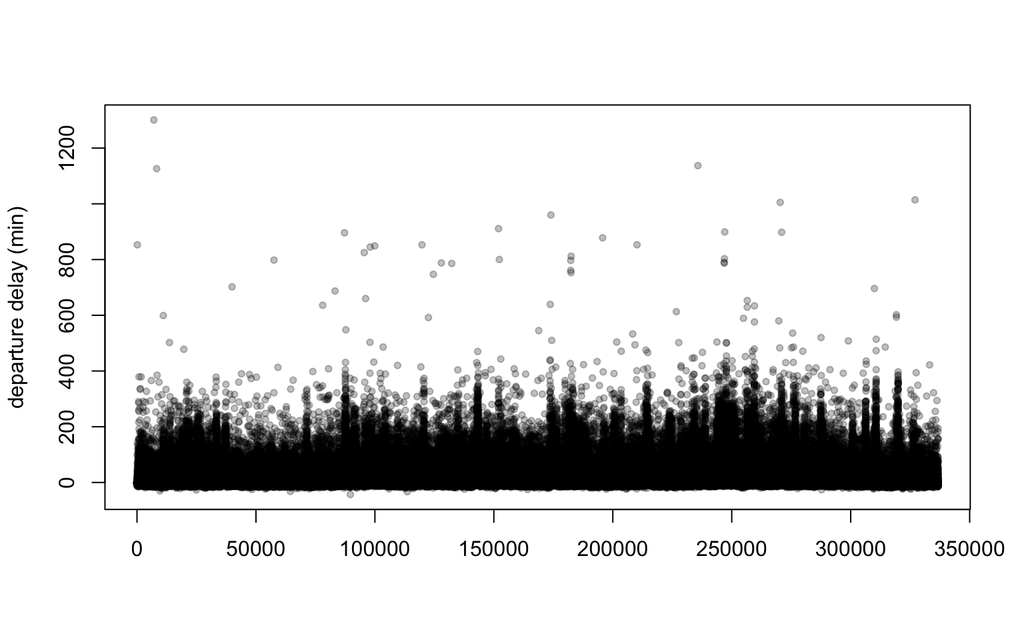

```r
plot(flights$dep_delay, xlab = "", ylab = "departure delay (min)", pch = 20, col = rgb(0,
    0, 0, 0.25))
```

*Note, I don’t recommend necessarily that you try and plot this yourself since it is very processor intensive to plot >300k points.* If you want to plot yourself, limit yourself to month 1.

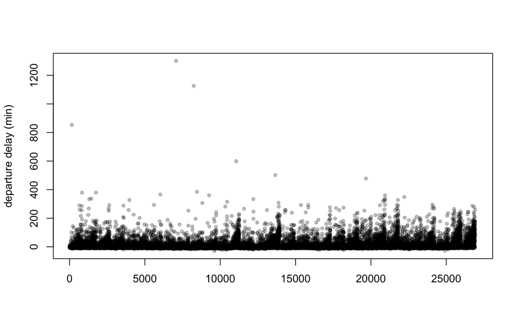

```r
plot(flights$dep_delay[flights$month == 1], xlab = "", ylab = "departure delay (min)",
    pch = 20, col = rgb(0, 0, 0, 0.25))
```

However you plot it, perhaps you see something that is thought provoking, namely that the data are not randomly distributed, but instead appear to have a clear sawtooth pattern. Some days were pretty bad, some days were not. One way to summarize this data would be to calculate a ‘rolling average’ of the departure delays. There are several strategies for this type of summary.

1. You could figure out how to present in a `for` loop the index positions of some set of index positions, and then increment them by some number each round, calculating the average of all the index positions in the window for each step.
2. You could do a ‘binned average’ approach, where you take successive groups of n observations, and average them.

Both of these can be achieved with `for` loops, and we will focus on the rolling average approach (#1 above).

First off, you have to think about how you will present both the ‘window’ and the ‘step’ to a `for` loop. The ‘step’ is the easiest, since it is the increment of the values you run your `for` loop over. (e.g., `for(i in 1 : 10)` will have an increment of 1, whereas `for(i in seq(1, 10, by = 2)` will have an increment of 2)).

To do the window, this involves a trick with how the index positions are presented to the function `mean` within the `for` loop. To get you thinking about this, if you want to have a window of size 3 over a vector that is 12 units long, then:

```r
# the first window will be over
1:3
```

```
## [1] 1 2 3
```

```r
# the second will be over
2:4
```

```
## [1] 2 3 4
```

```r
# the third will be over
3:5
```

```
## [1] 3 4 5
```

```r
# et cetera
```

**The challenge with this is 1) how to generalize those steps in the call to `mean`, 2) how to deal with the ends of the vector you are averaging over.**

In our example, if we want to have a step of 1 and a window of 3, for a target vector of length 12, then:

```r
target = c(1:12)
step = 1
win = 3

for (i in 1:(length(target) - (win - 1))) {
    cat(target[i:(i + win - 1)])
    cat("\n")
}
```

```
## 1 2 3
## 2 3 4
## 3 4 5
## 4 5 6
## 5 6 7
## 6 7 8
## 7 8 9
## 8 9 10
## 9 10 11
## 10 11 12
```

The code above just prints out to the workspace the index positions you would be looping through, using the function `cat`. But it highlights how you could set up a `for` loop to index through your target vector. The parts of this that are perhaps non-intuitive are 1) the need to subtract 1 from the size of the window; 2) the need to subtract one window size (minus one) from the length of the target vector.

- based on this discussion, calculate the rolling average for departure delays using a window size of 500, and a step of 1.

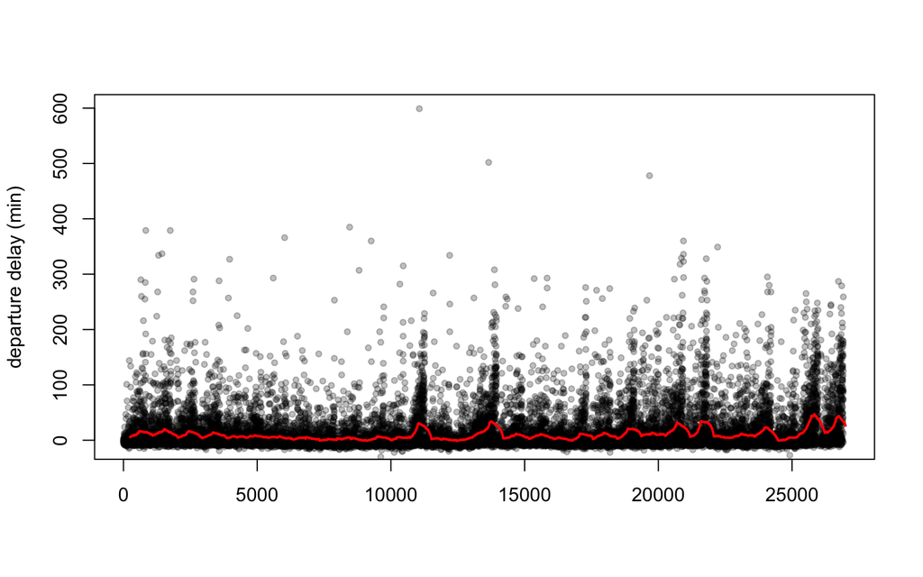

Looking at the January data, you should get something that looks like this (y-axis cropped slightly).

For a ‘binned average’, what we need to do is to break the data into distinct bins and average those. There are several ways to do this, but the way that follows from what we have already discussed is that *a binned average is a rolling average where the step size is equal to the window size.* Using our prior example, setting up the indices to loop over would work like this:

```r
target = c(1:12)
step = 3
win = 3

for (i in seq(1, (length(target) - (win - 1)), by = step)) {
    cat(target[i:(i + win - 1)])
    cat("\n")
}
```

```
## 1 2 3
## 4 5 6
## 7 8 9
## 10 11 12
```

- Calculate a binned average for the departure delay data with step size 100 and window size 100.

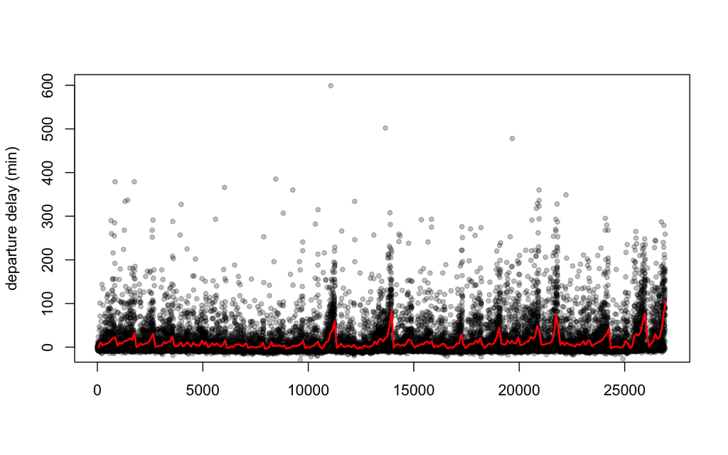

And you should get something that looks like this. Note that the benefit of a binned average is that it greatly reduces the size of the data you are trying to summarize, while capturing the overall trends.

*Bonus: you don’t just have to use continual indices in the `for` loop. For instance, you could use the `for` loop to calculate the average of every fifth element in 1000 element windows. The art of `for` looping is defining the values that `i` takes on in each loop. Note, however, that once you deviate from 1,2,3,… indexing, you begin to run into problems with using `i` to serve as the indexing variable for the output. For instance, if `i` will take on values of [5, 10, 15, 20] on the 1st, 2nd, 3rd, and 4th rounds of the loop, it is difficult to directly use the value of `i` to assign output to the 1st, 2nd, 3rd, and 4th element of the output object. You either have to multiply `i = 1,2,3,4` by 5 to do your calculation, or you have to divide `i = 5, 10, 15, 20` by 5 to do the assignment. Give it a shot if you are interested.*

### 4) Write a generalized function for computing binned/rolling averages

That binned/rolling average thing seems like it would be pretty good to do all the time. But do you want to remember how to properly index your `for` loop each time? (I had to remind myself from scratch when I wrote this.) No. You don’t. Make your life easier by writing a function that you can use whenever you want.

An ideal generalized function for binned/rolling average would take only three inputs: the data, the window size, and the step size. Remember, the difference between binned and rolling is just whether the step size is equal to the window size or not. However, we could also run into predictable problems, say if either the window size or the step size is not a whole number.

Looking back at the example in class of `median.default` there are strategies for building in checks to a function to make sure that the input data is in the form expected by the function.

- write a logical statement that will return FALSE if a value is numeric
- write a logical statement that will return FALSE when a numeric value is a whole number (hint, we discussed the `modulus` command `%%`).
- Incorporate these logical statements into `if` statements that, if TRUE, will exit the function and provide an error message. The command `return` will exit a function and provide an output.
- Now that you have explored quality control checks, write a new function, `rolledAverage` that will take any input vector, window, and step size, and output a rolled average. Incorporate the quality control checks from above.
- Test that the function will throw an error if the window size or the step size is set to a non whole number.
- Test that the function will calculate an identical binned average as you calculated above for departure delays. (Use the `identical` function.)

### Notes on working with custom functions:

As you write functions to create shortcuts for repetitive tasks, you can save them and load them to your R environment as needed. If you create a substantial number of these, and they are related, you may even want to consider building your own package to distribute or at least to install into R like other libraries from CRAN or Bioconductor.

If you write a function that you would like to use again, you can just save it like you would any R object. For instance, you could save `rolledAverage` as written above:

```r
save(rolledAverage, file = "~/Desktop/RolledAverage.R")
```

This would save the object `rolledAverage` to a file on your Desktop named RolledAverage.R (but it would be better to put this in a more respectable location on your computer, in general).

Then, when you want to use it, all you have to do is to `source` the saved file:

```r
source("~/Desktop/RolledAverage.R")
```

And it will be loaded up into your global environment ready for use in a new analysis.

Writing packages is beyond the scope of this class, but if you find yourself writing many functions to enhance your R experience, then it would be easy enough to learn how to add package forging to your repertoire.